# FLR Tutorials - Session 4

[FLR Project](https://flr-project.org)

Det er vanskeligt at spaa, især naar det gælder Fremtiden.

*It is difficult to make predictions, especially about the future.*

[Danish saying, attributed to Niels Bohr](https://quoteinvestigator.com/2013/10/20/no-predict/)

[figure not shown]

## FLasher::fwd(FLStock)

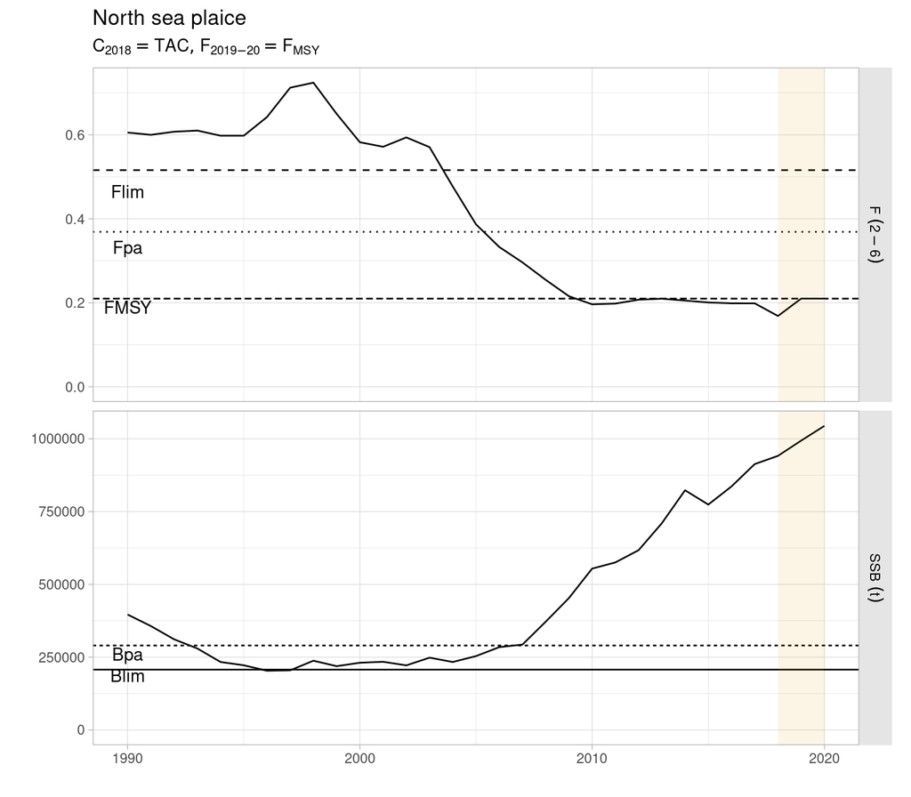

## 1. Prepare for the future

- Future biology
  - Weights-at-age (`wt`)
  - Natural mortality (`m`)
  - Maturity (`mat`)
  - Timing of spawning (`m.spwn`)
  - Stock-recruits relationship (`srr`)
- Future fleet dynamics
  - Selectivity (`harvest`)
  - Discards ratio (`landings`, `discards`)
  - Timing of fishing (`harvest.spwn`)

## 2. Set targets and limits

- When (`year`, `season`)
- What (`quant`)
- How much (`value`)
- How much bigger / smaller (`relYear`)
- No smaller and/or larger than (`min`, `max`)
- FLStock targets
  - `f`, `fbar`
  - `ssb_spawn`, `ssb_end`, `biomass_spawn`, `biomass_end`
  - `ssb_flash`, `biomass_flash`
  - `catch`, `landings`, `discards`
  - `revenue`

## 3. Run projection

- `fwd()`
- FLStock + FLSR/predictModel + fwdControl
- Recruitment `deviances`, in log scale
- `maxF`, maximum Fbar by timestep, `maxF=4`
- FLQuant / FLQuants as control `fwd(..., fbar=FLQuant(0.21, dimnames=list(year=2018)))`

## A quick projection

```r
# SET future biology and fishery
fut <- stf(ple4, nyears=3)

# CONSTRUCT SRR
srr <- predictModel(model=rec~a, params=FLPar(a=966808, units="1000"))

# SET targets
control <- fwdControl(year=2018:2020, quant="fbar", value=0.21)

# RUN fwd
fsy <- fwd(fut, sr=srr, control=control)

# TEST and ...
compare(fsy, control)
```

```
##   year quant achieved
## 1 2018  fbar     TRUE
## 2 2019  fbar     TRUE
## 3 2020  fbar     TRUE
```

## A quick projection

```r
# ... PROFIT!
```

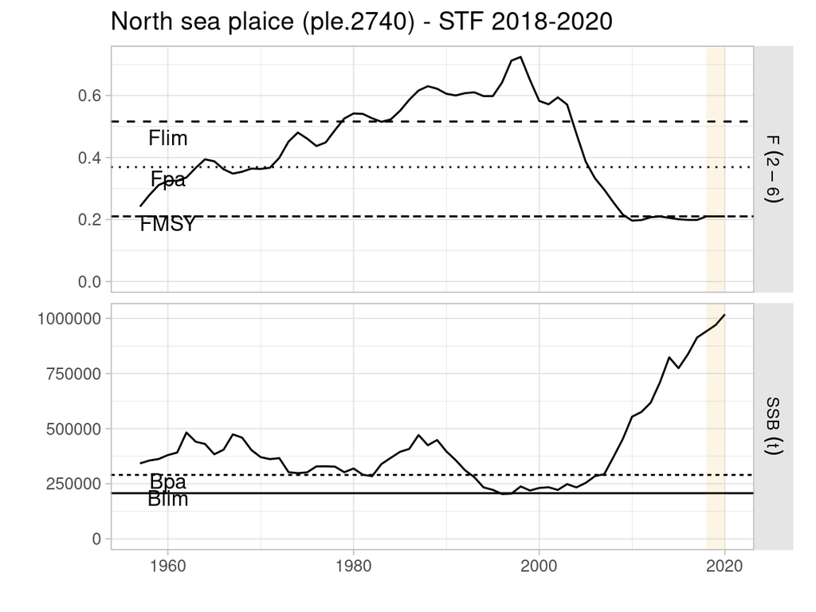

## Differences between FLash and FLasher

### fwdControl

- `quantity` is now `quant`
- `val` is now `value`
- `rel` is now `relYear`

### Internal

- Solves for effort, not F
- `Fmax` as part of target list

### Seasonal and multiple units (sex)

### Multi-fishery and multi-stock

## Timing and targets

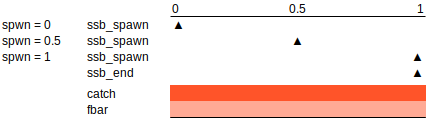

### FLash

- `ssb` target if `spwn = 0` solved for following year.

### FLasher

- `ssb_spawn` to solve at `spwn`.
- `ssb_end` to solve at end of timestep.
- `ssb_flash` to solve as FLash did.

## https://flr-project.org/FLasher

[figure not shown]